# Cálculos para metodologia de atenção primária

# Configurando ambiente e lendo dados

Carregando a biblioteca tidyverse

```r
library(tidyverse)
```

Lendo os dados

```r
cadastro_egestorab <- read_delim("https://raw.githubusercontent.com/wandersondsm/obs-cigets/main/analises-ad_hoc/dimensionamento/002%20-%20metodologia%20de%20aps/cadastro_egestorab.csv",";", escape_double = FALSE, locale = locale(date_names = "pt",
        encoding = "ISO-8859-1", asciify = TRUE), trim_ws = TRUE) %>%
  janitor::clean_names() %>%
  select(cnes, ine, total_1221)


cadastr_pop_ponderada <- read_delim("https://raw.githubusercontent.com/wandersondsm/obs-cigets/main/analises-ad_hoc/dimensionamento/002%20-%20metodologia%20de%20aps/cadastr_pop_ponderada.csv", ";", escape_double = FALSE, locale = locale(date_names = "pt",
        encoding = "ISO-8859-1", asciify = TRUE),
  trim_ws = TRUE) %>%
  janitor::clean_names()
```

Juntando as bases e a agrupando por código ibge, UF, município, CNES e nome da unidade de saúde

```r
df <- cadastro_egestorab %>%
        left_join(cadastr_pop_ponderada, by = c("cnes", "ine")) %>%
        group_by(ibge, uf, municipio, cnes, nome_ubs) %>%
        summarise(total_pop = sum(total_1221),
                  total_ponderada = sum(pop_ponderada)) %>%
        mutate(prop_vulneravel = round((total_ponderada/total_pop), 2))
DT::datatable(df)
```

|  | ibge | uf | municipio | cnes | nome_ubs | total_pop | total_ponderada | prop_vulneravel |
| --- | --- | --- | --- | --- | --- | --- | --- | --- |
| 1 | 520005 | GO | ABADIA DE GOIÁS | 9348352 | UBS RECANTO DOS DOURADOS | 1797 | 686 | 0.38 |
| 2 | 520005 | GO | ABADIA DE GOIÁS | 9655093 | UBS GORGONIO ALVES FORTES | 8868 | 2866 | 0.32 |
| 3 | 520010 | GO | ABADIÂNIA | 2361833 | UBS CENTRAL | 4838 | 1443 | 0.3 |
| 4 | 520010 | GO | ABADIÂNIA | 2383527 | UBS PLANALMIRA | 2710 | 803 | 0.3 |
| 5 | 520010 | GO | ABADIÂNIA | 3905683 | UBS EDUARDO ALMEIDA BALBINO | 3760 | 1250 | 0.33 |
| 6 | 520010 | GO | ABADIÂNIA | 6937756 | UBS LINDO HORIZONTE | 5052 | 1650 | 0.33 |
| 7 | 520013 | GO | ACREÚNA | 2383160 | U S F ANA CARLA | 7507 | 2563 | 0.34 |
| 8 | 520013 | GO | ACREÚNA | 2440229 | U S F SOL NASCENTE | 5669 | 1721 | 0.3 |
| 9 | 520013 | GO | ACREÚNA | 2440237 | UNIDADE DE SAUDE DA FAMILIA JOAQUIM DE O ATAIDE NETO | 3106 | 1040 | 0.33 |
| 10 | 520013 | GO | ACREÚNA | 2441241 | U S F ARANTINA | 1147 | 453 | 0.39 |

[output cut: 1198 more lines]

# Exemplo de cálculo de estratos de vulnerabilidade

A análise da população vulnerável é feita a partir de municípios. Vamos pegar o município de Goiânia como referência.

Conforme observado, a maior parte das unidades se concentram na faixa de 0,2 a 0,3 de vulnerabilidade.

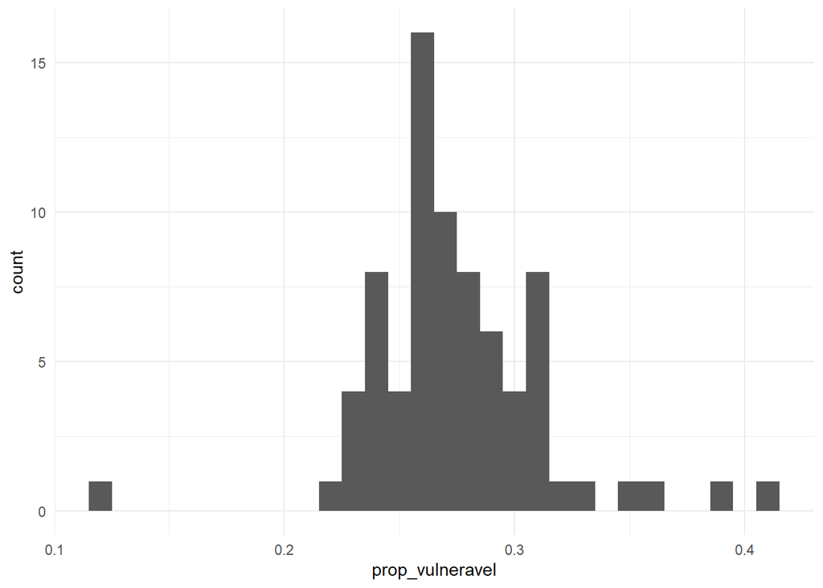

```r
df_gyn <- df %>%
            filter(ibge == "520870")


df_gyn %>%
  ggplot(aes(x = prop_vulneravel)) + geom_histogram() + theme_minimal()
```

# Definição de estratos de vulnerabilidade

Vamos pegar o exemplo de três estratos de vulnerabilidade. Para isso, vamos dividir nossa amostra em três intervalos baseados em medidas de posição: 33º percentil (divide os estratos baixo e médio), 66º percentil (divide os estratos médio e alto).

Para cada categoria de vulnerabilidade, são associados parâmetros de distribuição de equipes por população, conforme a PNAB. A coluna parâmetros estabelece esse resultado. Para vulnerabilidade baixa, a população é dividida por 3.500, para uma população de alta vulnerabilidade, a população é dividida pelo parâmetro de 2.000.

```r
# calculando percentis
q1 <- quantile(df_gyn$prop_vulneravel, probs = c(0.33))
q2 <- quantile(df_gyn$prop_vulneravel, probs = c(0.66))

# definindo os estratos a partir dos percentis
df_gyn <- df_gyn %>%
  mutate(vulnerabilidade = case_when(prop_vulneravel <= q1 ~ "Baixa",
                             prop_vulneravel > q1 & prop_vulneravel <= q2 ~ "Média",
                             prop_vulneravel > q2 ~ "Alta"),
         parametros = case_when(vulnerabilidade == "Baixa" ~ 3500,
                                vulnerabilidade == "Média" ~ 3000,
                                vulnerabilidade == "Alta" ~ 2000))


DT::datatable(df_gyn)
```

|  | ibge | uf | municipio | cnes | nome_ubs | total_pop | total_ponderada | prop_vulneravel | vulnerabilidade | parametros |
| --- | --- | --- | --- | --- | --- | --- | --- | --- | --- | --- |
| 1 | 520870 | GO | GOIÂNIA | 505994 | CENTRO DE SAUDE GOIA | 236 | 57 | 0.24 | Baixa | 3500 |
| 2 | 520870 | GO | GOIÂNIA | 506664 | CENTRO DE SAUDE VILA NOVA | 363 | 114 | 0.31 | Alta | 2000 |
| 3 | 520870 | GO | GOIÂNIA | 2338483 | CENTRO DE SAUDE NORTE FERROVIARIO | 2964 | 931 | 0.31 | Alta | 2000 |
| 4 | 520870 | GO | GOIÂNIA | 2338491 | CENTRO DE SAUDE CRIMEIA LESTE | 2971 | 780 | 0.26 | Baixa | 3500 |
| 5 | 520870 | GO | GOIÂNIA | 2338505 | CENTRO DE SAUDE JARDIM BALNEARIO MEIA PONTE | 4117 | 1205 | 0.29 | Alta | 2000 |
| 6 | 520870 | GO | GOIÂNIA | 2338521 | CENTRO DE SAUDE FAMA | 2658 | 745 | 0.28 | Média | 3000 |
| 7 | 520870 | GO | GOIÂNIA | 2338548 | USF VILA SANTA HELENA | 14475 | 4384 | 0.3 | Alta | 2000 |
| 8 | 520870 | GO | GOIÂNIA | 2338572 | CENTRO DE SAUDE MARINHO LEMOS | 2679 | 705 | 0.26 | Baixa | 3500 |
| 9 | 520870 | GO | GOIÂNIA | 2339269 | USF ARUANA III | 7665 | 1853 | 0.24 | Baixa | 3500 |
| 10 | 520870 | GO | GOIÂNIA | 2339277 | CENTRO DE SAUDE CONJUNTO RIVIERA | 3623 | 932 | 0.26 | Baixa | 3500 |

[output cut: 66 more lines]

# Calculando o total de equipes por unidade

```r
df_gyn <- df_gyn %>%
  mutate(total_equipes = total_pop/parametros)

sum(df_gyn$total_equipes)
```

```
## [1] 236.47
```

# Calculando o total de profissionais necessários

O total de profissionais é pela PNAB. Casos em que a política não é mais flexível, o usuário pode ajustar, como o caso de técnicos de enfermagem e agentes comunitários de saúde.

```r
df_gyn <- df_gyn %>%
            mutate(medicos = total_equipes * 1,
                   enfermeiros = total_equipes * 1,
                   tecnicos = total_equipes * 2,
                   acs = total_pop/750)
```

# Limitações

Essa é uma metodologia que é limitada pela qualidade do dado de entrada. O número da população adscrita é proporcional à capacidade de uma unidade atender a população do seu território. Unidades com maior capacidade operacional, representarão melhor a realidade dos dados. Por isso, pode ser necessário incluir dados primários no desenvolvimento da metodologia, especialmente em relação à população adscrita e os indicadores de vulnerabilidade.

Além disso, é uma metodologia que utiliza como referência as unidades e não o território. Portanto, áreas que não são cobertas pela atenção primária, ainda que de alta vulnerabilidade, não serão contempladas na análise.